# Dynamics of seroprevalence and effect of vaccination

## Packages

The required packages:

```r
> required_packages <- c("dplyr", "magrittr", "purrr", "readxl")
> to_install <- setdiff(required_packages, rownames(installed.packages()))
> if (length(to_install)) install.packages(to_install)
```

Laoding the packages for interactive use:

```r
> library(magrittr)
```

## Loading the data

Let’s load and transform the data

```r
> serodata <- readxl::read_excel("SeroData.xlsx") %>%
+   dplyr::mutate_at("Weight.Kg.", as.numeric) %>%
+   dplyr::mutate_at(dplyr::vars(dplyr::starts_with("Sero")), as.logical) %>%
+   dplyr::mutate_at(dplyr::vars(dplyr::ends_with("vaccinated")), as.logical) %>%
+   dplyr::rename(age = `Age(Week)`)
Warning: NAs introduits lors de la conversion automatique
```

Number of observations:

```r
> nrow(serodata)
[1] 267
```

Number of unique flocks:

```r
> length(unique(serodata$FlockID))
[1] 267
```

(i.e. one observation per flock). Number of farms:

```r
> length(unique(serodata$`Farm ID`))
[1] 100
```

Number of flocks per farm:

```r
> serodata %>%
+   dplyr::group_by(`Farm ID`) %>%
+   dplyr::tally() %>%
+   purrr::pluck("n") %>%
+   table()
.
 1  2  3  4  5  6  7  8 11
35 23 14 11 11  2  2  1  1
```

Ages:

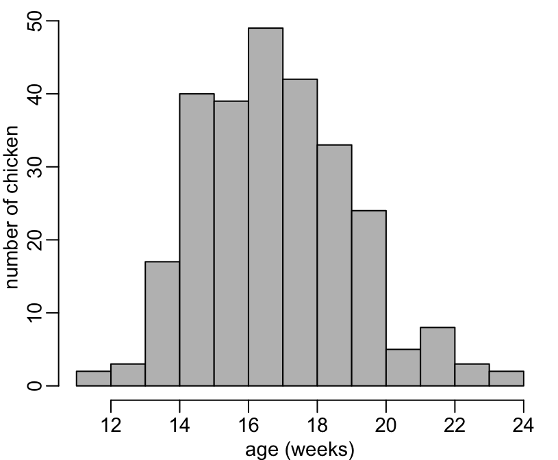

```r
> hist(serodata$age, col = "grey", main = NA, xlab = "age (weeks)", ylab = "number of chicken")
```

Weights:

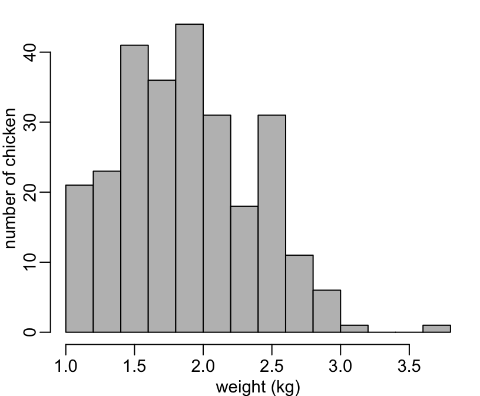

```r
> hist(serodata$Weight.Kg., col = "grey", main = NA, xlab = "weight (kg)", ylab = "number of chicken")
```

No correlation between age and weight:

```r
> summary(lm(Weight.Kg. ~ age, serodata))

Call:
lm(formula = Weight.Kg. ~ age, data = serodata)

Residuals:
     Min       1Q   Median       3Q      Max
-0.96443 -0.37720 -0.02499  0.33004  1.86397

Coefficients:
            Estimate Std. Error t value Pr(>|t|)
(Intercept)  2.12222    0.23855   8.896   <2e-16 ***
age         -0.01105    0.01400  -0.789    0.431
---
Signif. codes:  0 '***' 0.001 '**' 0.01 '*' 0.05 '.' 0.1 ' ' 1

Residual standard error: 0.4943 on 262 degrees of freedom
  (3 observations deleted due to missingness)
Multiple R-squared:  0.002369,  Adjusted R-squared:  -0.001439
F-statistic: 0.6221 on 1 and 262 DF,  p-value: 0.431
```

Visually:

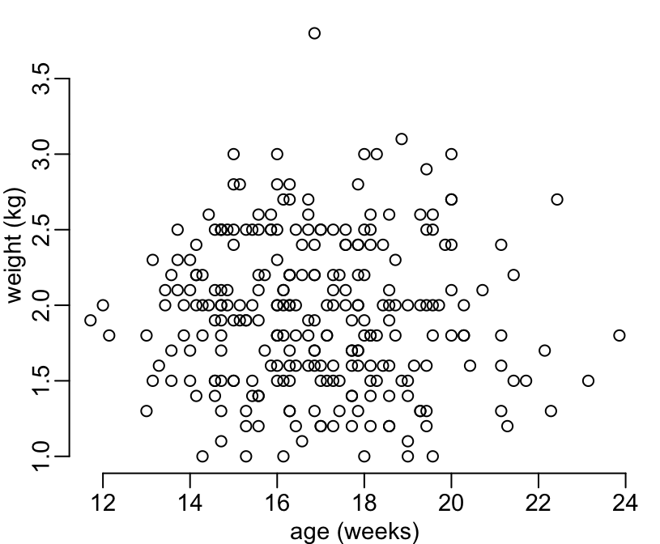

```r
> with(serodata, plot(age, Weight.Kg., xlab = "age (weeks)", ylab = "weight (kg)"))
```

Flock sizes:

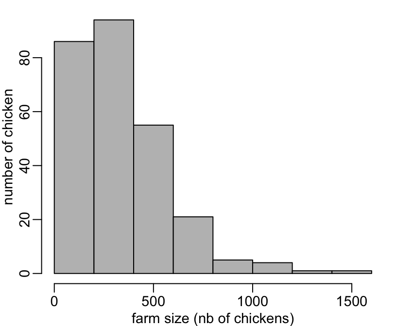

```r
> hist(serodata$Farmsize, col = "grey", xlab = "farm size (nb of chickens)", ylab = "number of chicken")
```

No correlation between farm size and weight:

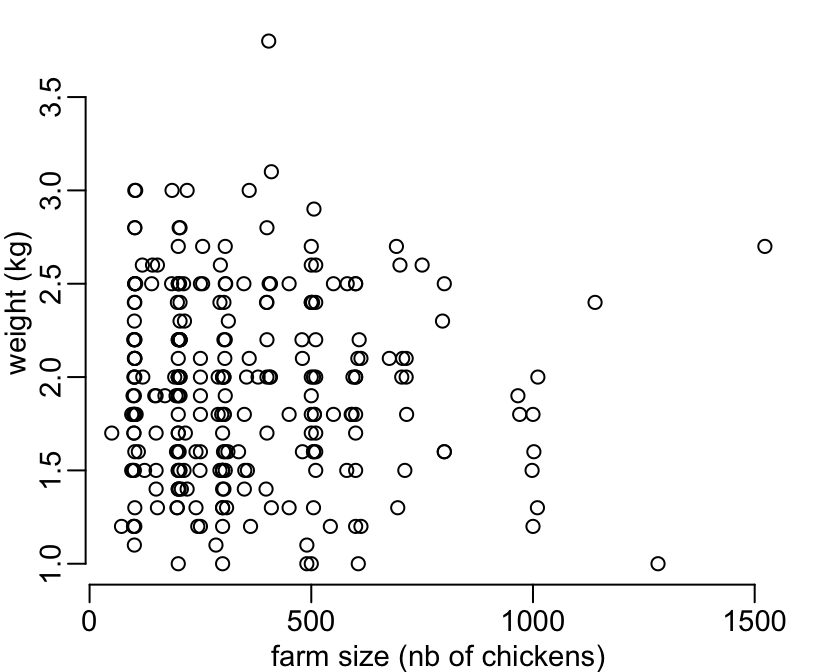

```r
> summary(lm(Weight.Kg. ~ Farmsize, serodata))

Call:
lm(formula = Weight.Kg. ~ Farmsize, data = serodata)

Residuals:
     Min       1Q   Median       3Q      Max
-0.94609 -0.39502 -0.03182  0.35437  1.86825

Coefficients:
              Estimate Std. Error t value Pr(>|t|)
(Intercept)  1.960e+00  5.390e-02  36.365   <2e-16 ***
Farmsize    -7.032e-05  1.274e-04  -0.552    0.582
---
Signif. codes:  0 '***' 0.001 '**' 0.01 '*' 0.05 '.' 0.1 ' ' 1

Residual standard error: 0.4946 on 262 degrees of freedom
  (3 observations deleted due to missingness)
Multiple R-squared:  0.001161,  Adjusted R-squared:  -0.002651
F-statistic: 0.3045 on 1 and 262 DF,  p-value: 0.5815
> with(serodata, plot(Farmsize, Weight.Kg., xlab = "farm size (nb of chickens)", ylab = "weight (kg)"))
```

But age seems to increase with farm size:

```r
> summary(lm(age ~ Farmsize, serodata))

Call:
lm(formula = age ~ Farmsize, data = serodata)

Residuals:
    Min      1Q  Median      3Q     Max
-5.0276 -1.3600 -0.0966  1.3882  6.0929

Coefficients:
             Estimate Std. Error t value Pr(>|t|)
(Intercept) 1.572e+01  2.198e-01  71.500  < 2e-16 ***
Farmsize    3.324e-03  5.187e-04   6.408 6.72e-10 ***
---
Signif. codes:  0 '***' 0.001 '**' 0.01 '*' 0.05 '.' 0.1 ' ' 1

Residual standard error: 2.024 on 265 degrees of freedom
Multiple R-squared:  0.1341,    Adjusted R-squared:  0.1309
F-statistic: 41.06 on 1 and 265 DF,  p-value: 6.72e-10
```

Visually:

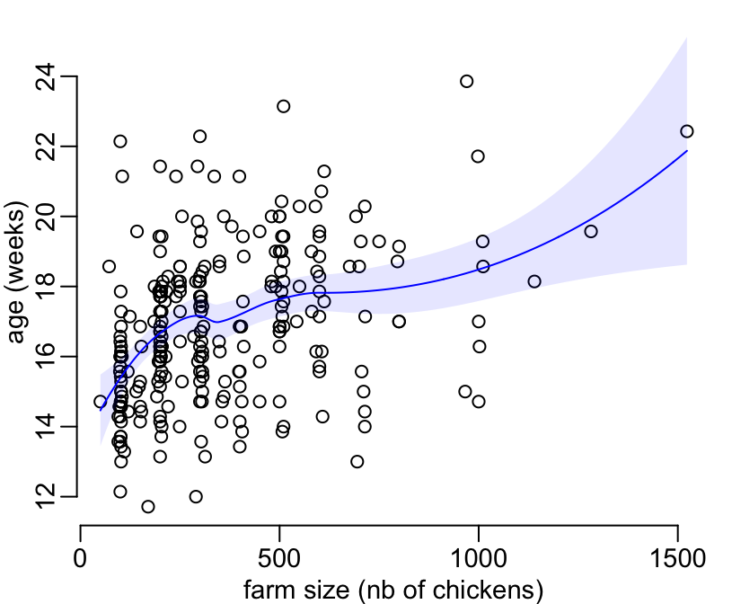

```r
> mod <- loess(age ~ Farmsize, serodata)
> x_val <- with(serodata, seq(min(Farmsize), max(Farmsize), le = 512))
> pred <- predict(mod, data.frame(Farmsize = x_val), se = TRUE)
> y_val <- with(pred, c(fit + qt(.025, Inf) * se.fit, rev(fit + qt(.975, Inf) * se.fit)))
> with(serodata, plot(Farmsize, age, xlab = "farm size (nb of chickens)",
+                     ylab = "age (weeks)",
+                     ylim = c(min(c(age, y_val)), max(c(age, y_val)))))
> polygon(c(x_val, rev(x_val)), y_val, col = adjustcolor("blue", .1), border = NA)
> lines(x_val, pred$fit, col = "blue")
```

## Modelling seropositivity as a function of age and vaccination

The following function makes a data frame for a given disease `var`, with 3 columns: `age`, `seropositive` and `vaccinated`:

```r
> make_data <- function(var) {
+   a <- dplyr::select(serodata, age, dplyr::contains(var))
+   sel <- grep("vaccinated", names(a))
+   if (length(sel) > 0) {
+     setNames(a, c("age", "seropositive", "vaccinated"))
+   }
+   dplyr::mutate(a, vaccinated = FALSE) %>%
+     setNames(c("age", "seropositive", "vaccinated"))
+ }
```

The 8 diseases:

```r
> vars <- sub("Sero.", "", grep("Sero", names(serodata), value = TRUE))
```

Making the data sets for all the diseases:

```r
> datasets <- setNames(lapply(vars, make_data), vars)
```

Checking which diseases have vaccination:

```r
> vaccinated <- datasets %>%
+   sapply(function(x) length(unique(unlist(x[, "vaccinated"]))) > 1)
```

Looking at the effect of age and vaccination for all the diseases with vaccination:

```r
> lapply(datasets[vaccinated], function(x)
+                                glm(seropositive ~ age * vaccinated, binomial, x) %>%
+                                anova(test = "LRT"))
$AI
Analysis of Deviance Table

Model: binomial, link: logit

Response: seropositive

Terms added sequentially (first to last)

               Df Deviance Resid. Df Resid. Dev Pr(>Chi)
NULL                             266     327.71
age             1  0.41993       265     327.29   0.5170
vaccinated      1  0.10356       264     327.19   0.7476
age:vaccinated  1  0.11031       263     327.08   0.7398

$IBD
Analysis of Deviance Table

Model: binomial, link: logit

Response: seropositive

Terms added sequentially (first to last)

               Df Deviance Resid. Df Resid. Dev Pr(>Chi)
NULL                             266     103.94
age             1  0.19178       265     103.75   0.6614
vaccinated      1  1.65084       264     102.09   0.1988
age:vaccinated  1  1.62724       263     100.47   0.2021

$NDV
Analysis of Deviance Table

Model: binomial, link: logit

Response: seropositive

Terms added sequentially (first to last)

               Df Deviance Resid. Df Resid. Dev Pr(>Chi)
NULL                             266     351.03
age             1  0.15777       265     350.87   0.6912
vaccinated      1  1.58348       264     349.29   0.2083
age:vaccinated  1  0.13050       263     349.16   0.7179

$IBV
Analysis of Deviance Table

Model: binomial, link: logit

Response: seropositive

Terms added sequentially (first to last)

               Df Deviance Resid. Df Resid. Dev Pr(>Chi)
NULL                             266     329.36
age             1   8.2442       265     321.11 0.004088 **
vaccinated      1   2.6885       264     318.42 0.101074
age:vaccinated  1   0.4396       263     317.98 0.507339
---
Signif. codes:  0 '***' 0.001 '**' 0.01 '*' 0.05 '.' 0.1 ' ' 1

$PM
Analysis of Deviance Table

Model: binomial, link: logit

Response: seropositive

Terms added sequentially (first to last)

               Df Deviance Resid. Df Resid. Dev Pr(>Chi)
NULL                             266     109.80
age             1   4.1777       265     105.62  0.04096 *
vaccinated      1   1.7005       264     103.92  0.19223
age:vaccinated  1   3.1914       263     100.73  0.07403 .
---
Signif. codes:  0 '***' 0.001 '**' 0.01 '*' 0.05 '.' 0.1 ' ' 1
```

The only disease for which vaccination may have a slight effect is PM:

```r
> summary(glm(seropositive ~ age + vaccinated, binomial, datasets[["PM"]]))

Call:
glm(formula = seropositive ~ age + vaccinated, family = binomial,
    data = datasets[["PM"]])

Deviance Residuals:
    Min       1Q   Median       3Q      Max
-0.6846  -0.3591  -0.2803  -0.2255   2.6614

Coefficients:
               Estimate Std. Error z value Pr(>|z|)
(Intercept)     -7.1855     2.2314  -3.220  0.00128 **
age              0.2296     0.1240   1.851  0.06420 .
vaccinatedTRUE   0.7376     0.5603   1.316  0.18807
---
Signif. codes:  0 '***' 0.001 '**' 0.01 '*' 0.05 '.' 0.1 ' ' 1

(Dispersion parameter for binomial family taken to be 1)

    Null deviance: 109.80  on 266  degrees of freedom
Residual deviance: 103.92  on 264  degrees of freedom
AIC: 109.92

Number of Fisher Scoring iterations: 6
```

and

```r
> summary(glm(seropositive ~ age * vaccinated, binomial, datasets[["PM"]]))

Call:
glm(formula = seropositive ~ age * vaccinated, family = binomial,
    data = datasets[["PM"]])

Deviance Residuals:
    Min       1Q   Median       3Q      Max
-0.9319  -0.4210  -0.2657  -0.1724   2.8104

Coefficients:
                   Estimate Std. Error z value Pr(>|z|)
(Intercept)        -10.6914     3.0955  -3.454 0.000553 ***
age                  0.4226     0.1651   2.559 0.010494 *
vaccinatedTRUE       8.6247     4.4549   1.936 0.052867 .
age:vaccinatedTRUE  -0.4394     0.2470  -1.779 0.075201 .
---
Signif. codes:  0 '***' 0.001 '**' 0.01 '*' 0.05 '.' 0.1 ' ' 1

(Dispersion parameter for binomial family taken to be 1)

    Null deviance: 109.80  on 266  degrees of freedom
Residual deviance: 100.73  on 263  degrees of freedom
AIC: 108.73

Number of Fisher Scoring iterations: 6
```

Not only the effect of vaccination would be small be it wouldn’t even be in the right directions…

The following function computes a data frame with 512 rows and 4 columns: one for age, one for predicted seroprevalence and the last two for the lower and upper bounds of the confidence interval:

```r
> predict2 <- function(x) {
+   require(magrittr)
+   linkinv <- family(x)$linkinv
+   ages <- x$data$age
+   age_val <- seq(min(ages), max(ages), le = 512)
+   predict(x, data.frame(age = age_val), se.fit = TRUE) %>%
+     data.frame() %>%
+     dplyr::mutate(lower = linkinv(fit + qt(.025, Inf) * se.fit),
+                   upper = linkinv(fit + qt(.975, Inf) * se.fit),
+                   fit   = linkinv(fit),
+                   age   = age_val) %>%
+     dplyr::select(-residual.scale, -se.fit)
+ }
```

The following function takes the output of the `predict2()` function as an input and draws a figure with model predicted seroprevalence as a function of age:

```r
> plot_pred <- function(x) {
+   plot(x$age, x$fit, xlim = c(12, 24), ylim = 0:1, type = "n", xlab = "age (weeks)", ylab = "seroprevalence")
+   polygon(c(x$age, rev(x$age)), c(x$lower, rev(x$upper)), col = adjustcolor("blue", .2), border = NA)
+   lines(x$age, x$fit, col = "blue")
+ }
```

```r
> models <- lapply(datasets, function(x) glm(seropositive ~ age, binomial, x))
```

Computing the models predictions:

```r
> predictions <- lapply(models, predict2)
```

Plotting the models’ predictions:

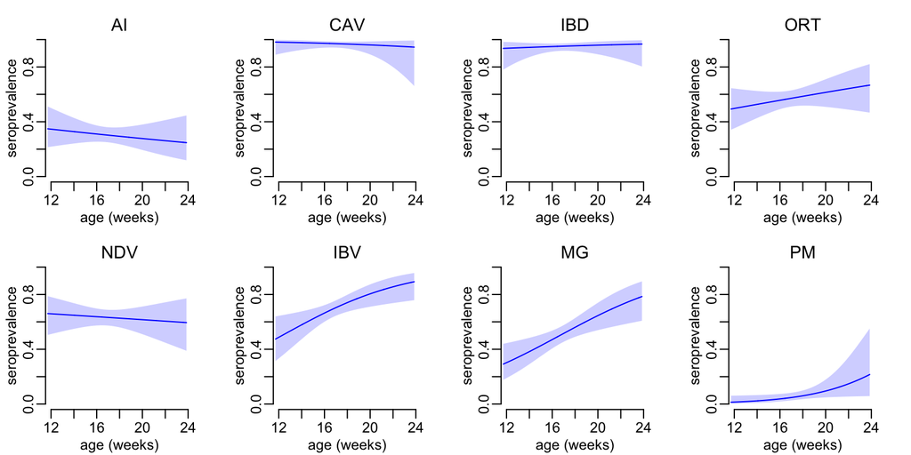

```r
> opar <- par(mfrow = c(2, 4), cex = .83, plt = c(.2, .85, .2, .85))
> for (i in seq_along(vars)) {
+   plot_pred(predictions[[i]])
+   mtext(vars[i], line = 0)
+ }
```

```r
> par(opar)
```

## The relationship between vaccination and diseases episodes

Loading the ViParc data:

```r
> viparc <- readr::read_csv("https://raw.githubusercontent.com/viparc/clires_data/master/data/viparc.csv",
+                           col_types = paste(rep(c("c", "i", "l", "i", "d", "l", "d"), c(1, 2, 2, 1, 3, 6, 45)), collapse = "")) %>%
+   dplyr::mutate(FlockID = paste0(farm, flock)) %>%
+   dplyr::semi_join(serodata, by = "FlockID") %>%
+   dplyr::group_by(FlockID) %>%
+   dplyr::summarise(duration    = n(),
+                    respiratory = sum(respiratory),
+                    diarrhoea   = sum(diarrhoea),
+                    cns         = sum(cns),
+                    mortality   = sum(sudden_death)) %>%
+   dplyr::left_join(serodata, "FlockID")
Warning: Calling `n()` without importing or prefixing it is deprecated, use `dplyr::n()`.
This warning is displayed once per session.
```

HPAI and IBV vaccines tend to be associated with higher prevalence of respiratory symptoms. Is it because vaccines are responsive? NDV and IBD vaccines have no effects on the prevalence of respiratory symptoms.

```r
> summary(glm(cbind(respiratory, duration - respiratory) ~ NDV.vaccinated, binomial, viparc))

Call:
glm(formula = cbind(respiratory, duration - respiratory) ~ NDV.vaccinated,
    family = binomial, data = viparc)

Deviance Residuals:
    Min       1Q   Median       3Q      Max
-1.4977  -1.2564  -1.1530   0.1566   7.9685

Coefficients:
                   Estimate Std. Error z value Pr(>|z|)
(Intercept)         -3.2690     0.3851  -8.489   <2e-16 ***
NDV.vaccinatedTRUE   0.1088     0.3921   0.277    0.781
---
Signif. codes:  0 '***' 0.001 '**' 0.01 '*' 0.05 '.' 0.1 ' ' 1

(Dispersion parameter for binomial family taken to be 1)

    Null deviance: 683.61  on 266  degrees of freedom
Residual deviance: 683.53  on 265  degrees of freedom
AIC: 868.59

Number of Fisher Scoring iterations: 5
> summary(glm(cbind(respiratory, duration - respiratory) ~ HPAI.vaccinated, binomial, viparc))

Call:
glm(formula = cbind(respiratory, duration - respiratory) ~ HPAI.vaccinated,
    family = binomial, data = viparc)

Deviance Residuals:
    Min       1Q   Median       3Q      Max
-1.5441  -1.2608  -1.1887   0.1222   7.8653

Coefficients:
                    Estimate Std. Error z value Pr(>|z|)
(Intercept)          -3.6163     0.2266 -15.960   <2e-16 ***
HPAI.vaccinatedTRUE   0.5184     0.2392   2.167   0.0302 *
---
Signif. codes:  0 '***' 0.001 '**' 0.01 '*' 0.05 '.' 0.1 ' ' 1

(Dispersion parameter for binomial family taken to be 1)

    Null deviance: 683.61  on 266  degrees of freedom
Residual deviance: 678.27  on 265  degrees of freedom
AIC: 863.33

Number of Fisher Scoring iterations: 5
> summary(glm(cbind(respiratory, duration - respiratory) ~ IBV.vaccinated, binomial, viparc))

Call:
glm(formula = cbind(respiratory, duration - respiratory) ~ IBV.vaccinated,
    family = binomial, data = viparc)

Deviance Residuals:
    Min       1Q   Median       3Q      Max
-1.6460  -1.2349  -1.1110   0.0415   7.4383

Coefficients:
                   Estimate Std. Error z value Pr(>|z|)
(Intercept)        -3.29754    0.08931 -36.922  < 2e-16 ***
IBV.vaccinatedTRUE  0.45144    0.15342   2.943  0.00325 **
---
Signif. codes:  0 '***' 0.001 '**' 0.01 '*' 0.05 '.' 0.1 ' ' 1

(Dispersion parameter for binomial family taken to be 1)

    Null deviance: 683.61  on 266  degrees of freedom
Residual deviance: 675.36  on 265  degrees of freedom
AIC: 860.42

Number of Fisher Scoring iterations: 5
> summary(glm(cbind(respiratory, duration - respiratory) ~ IBD.vaccinated, binomial, viparc))

Call:
glm(formula = cbind(respiratory, duration - respiratory) ~ IBD.vaccinated,
    family = binomial, data = viparc)

Deviance Residuals:
    Min       1Q   Median       3Q      Max
-1.5229  -1.2435  -1.1724   0.1486   7.9122

Coefficients:
                   Estimate Std. Error z value Pr(>|z|)
(Intercept)         -3.3945     0.2033 -16.695   <2e-16 ***
IBD.vaccinatedTRUE   0.2684     0.2177   1.233    0.218
---
Signif. codes:  0 '***' 0.001 '**' 0.01 '*' 0.05 '.' 0.1 ' ' 1

(Dispersion parameter for binomial family taken to be 1)

    Null deviance: 683.61  on 266  degrees of freedom
Residual deviance: 682.00  on 265  degrees of freedom
AIC: 867.06

Number of Fisher Scoring iterations: 5
> summary(glm(cbind(respiratory, duration - respiratory) ~ NDV.vaccinated + HPAI.vaccinated + IBV.vaccinated + IBD.vaccinated, binomial, viparc))

Call:
glm(formula = cbind(respiratory, duration - respiratory) ~ NDV.vaccinated +
    HPAI.vaccinated + IBV.vaccinated + IBD.vaccinated, family = binomial,
    data = viparc)

Deviance Residuals:
   Min      1Q  Median      3Q     Max
-1.703  -1.260  -1.121   0.016   7.317

Coefficients:
                    Estimate Std. Error z value Pr(>|z|)
(Intercept)          -3.7712     0.4500  -8.381  < 2e-16 ***
NDV.vaccinatedTRUE   -0.1045     0.4040  -0.259  0.79593
HPAI.vaccinatedTRUE   0.4824     0.2401   2.009  0.04456 *
IBV.vaccinatedTRUE    0.4312     0.1554   2.774  0.00554 **
IBD.vaccinatedTRUE    0.1860     0.2240   0.830  0.40626
---
Signif. codes:  0 '***' 0.001 '**' 0.01 '*' 0.05 '.' 0.1 ' ' 1

(Dispersion parameter for binomial family taken to be 1)

    Null deviance: 683.61  on 266  degrees of freedom
Residual deviance: 669.74  on 262  degrees of freedom
AIC: 860.8

Number of Fisher Scoring iterations: 5
> car::Anova(glm(cbind(respiratory, duration - respiratory) ~ NDV.vaccinated + HPAI.vaccinated + IBV.vaccinated + IBD.vaccinated, binomial, viparc), test = "LR")
Analysis of Deviance Table (Type II tests)

Response: cbind(respiratory, duration - respiratory)
                LR Chisq Df Pr(>Chisq)
NDV.vaccinated    0.0651  1   0.798566
HPAI.vaccinated   4.5415  1   0.033083 *
IBV.vaccinated    7.3750  1   0.006614 **
IBD.vaccinated    0.7176  1   0.396929
---
Signif. codes:  0 '***' 0.001 '**' 0.01 '*' 0.05 '.' 0.1 ' ' 1
```

NDV vaccine is marginally associated with higher prevalence of CNS. Does it reflect responsive vaccination? HPAI vaccine has no effect of the prevalence of CNS symptom.

```r
> summary(glm(cbind(cns, duration - cns) ~ NDV.vaccinated, binomial, viparc))

Call:
glm(formula = cbind(cns, duration - cns) ~ NDV.vaccinated, family = binomial,
    data = viparc)

Deviance Residuals:
    Min       1Q   Median       3Q      Max
-0.7049  -0.5914  -0.5756  -0.5254   3.5991

Coefficients:
                   Estimate Std. Error z value Pr(>|z|)
(Intercept)          -20.61    1310.86  -0.016    0.987
NDV.vaccinatedTRUE    15.93    1310.86   0.012    0.990

(Dispersion parameter for binomial family taken to be 1)

    Null deviance: 202.30  on 266  degrees of freedom
Residual deviance: 198.85  on 265  degrees of freedom
AIC: 264.77

Number of Fisher Scoring iterations: 17
> summary(glm(cbind(cns, duration - cns) ~ HPAI.vaccinated, binomial, viparc))

Call:
glm(formula = cbind(cns, duration - cns) ~ HPAI.vaccinated, family = binomial,
    data = viparc)

Deviance Residuals:
    Min       1Q   Median       3Q      Max
-0.7073  -0.5933  -0.5612  -0.5125   3.5939

Coefficients:
                    Estimate Std. Error z value Pr(>|z|)
(Intercept)          -5.0226     0.4487 -11.194   <2e-16 ***
HPAI.vaccinatedTRUE   0.3456     0.4774   0.724    0.469
---
Signif. codes:  0 '***' 0.001 '**' 0.01 '*' 0.05 '.' 0.1 ' ' 1

(Dispersion parameter for binomial family taken to be 1)

    Null deviance: 202.30  on 266  degrees of freedom
Residual deviance: 201.73  on 265  degrees of freedom
AIC: 267.64

Number of Fisher Scoring iterations: 6
> summary(glm(cbind(cns, duration - cns) ~ HPAI.vaccinated + NDV.vaccinated, binomial, viparc))

Call:
glm(formula = cbind(cns, duration - cns) ~ HPAI.vaccinated +
    NDV.vaccinated, family = binomial, data = viparc)

Deviance Residuals:
    Min       1Q   Median       3Q      Max
-0.7212  -0.6050  -0.5723  -0.5110   3.5627

Coefficients:
                     Estimate Std. Error z value Pr(>|z|)
(Intercept)          -20.8922  1308.6566  -0.016    0.987
HPAI.vaccinatedTRUE    0.3389     0.4774   0.710    0.478
NDV.vaccinatedTRUE    15.9155  1308.6565   0.012    0.990

(Dispersion parameter for binomial family taken to be 1)

    Null deviance: 202.3  on 266  degrees of freedom
Residual deviance: 198.3  on 264  degrees of freedom
AIC: 266.22

Number of Fisher Scoring iterations: 17
> car::Anova(glm(cbind(cns, duration - cns) ~ HPAI.vaccinated + NDV.vaccinated, binomial, viparc), test = "LR")
Analysis of Deviance Table (Type II tests)

Response: cbind(cns, duration - cns)
                LR Chisq Df Pr(>Chisq)
HPAI.vaccinated   0.5487  1     0.4588
NDV.vaccinated    3.4227  1     0.0643 .
---
Signif. codes:  0 '***' 0.001 '**' 0.01 '*' 0.05 '.' 0.1 ' ' 1
```

Vaccine against *P. multocida* seems to protect against mortality. NDV and HPAI have no effect on mortality.

```r
> summary(glm(cbind(mortality, duration - mortality) ~ HPAI.vaccinated, binomial, viparc))

Call:
glm(formula = cbind(mortality, duration - mortality) ~ HPAI.vaccinated,
    family = binomial, data = viparc)

Deviance Residuals:
    Min       1Q   Median       3Q      Max
-1.4558  -1.1455  -1.0561   0.2475   7.0654

Coefficients:
                    Estimate Std. Error z value Pr(>|z|)
(Intercept)          -3.0979     0.1780 -17.408   <2e-16 ***
HPAI.vaccinatedTRUE  -0.3028     0.1986  -1.525    0.127
---
Signif. codes:  0 '***' 0.001 '**' 0.01 '*' 0.05 '.' 0.1 ' ' 1

(Dispersion parameter for binomial family taken to be 1)

    Null deviance: 560.62  on 266  degrees of freedom
Residual deviance: 558.42  on 265  degrees of freedom
AIC: 731.55

Number of Fisher Scoring iterations: 5
> summary(glm(cbind(mortality, duration - mortality) ~ PM.vaccinated, binomial, viparc))

Call:
glm(formula = cbind(mortality, duration - mortality) ~ PM.vaccinated,
    family = binomial, data = viparc)

Deviance Residuals:
    Min       1Q   Median       3Q      Max
-1.4529  -1.2329  -0.9166   0.1412   6.6485

Coefficients:
                  Estimate Std. Error z value Pr(>|z|)
(Intercept)       -3.14365    0.08694 -36.158  < 2e-16 ***
PM.vaccinatedTRUE -0.84995    0.20959  -4.055 5.01e-05 ***
---
Signif. codes:  0 '***' 0.001 '**' 0.01 '*' 0.05 '.' 0.1 ' ' 1

(Dispersion parameter for binomial family taken to be 1)

    Null deviance: 560.62  on 266  degrees of freedom
Residual deviance: 541.19  on 265  degrees of freedom
AIC: 714.32

Number of Fisher Scoring iterations: 5
> summary(glm(cbind(mortality, duration - mortality) ~ NDV.vaccinated, binomial, viparc))

Call:
glm(formula = cbind(mortality, duration - mortality) ~ NDV.vaccinated,
    family = binomial, data = viparc)

Deviance Residuals:
    Min       1Q   Median       3Q      Max
-1.3210  -1.1516  -1.0893   0.2957   6.9649

Coefficients:
                   Estimate Std. Error z value Pr(>|z|)
(Intercept)         -3.6163     0.4532  -7.980 1.47e-15 ***
NDV.vaccinatedTRUE   0.2786     0.4602   0.605    0.545
---
Signif. codes:  0 '***' 0.001 '**' 0.01 '*' 0.05 '.' 0.1 ' ' 1

(Dispersion parameter for binomial family taken to be 1)

    Null deviance: 560.62  on 266  degrees of freedom
Residual deviance: 560.22  on 265  degrees of freedom
AIC: 733.35

Number of Fisher Scoring iterations: 5
> summary(glm(cbind(mortality, duration - mortality) ~ NDV.vaccinated + HPAI.vaccinated + PM.vaccinated, binomial, viparc))

Call:
glm(formula = cbind(mortality, duration - mortality) ~ NDV.vaccinated +
    HPAI.vaccinated + PM.vaccinated, family = binomial, data = viparc)

Deviance Residuals:
    Min       1Q   Median       3Q      Max
-1.4458  -1.2229  -0.8969   0.0916   6.6759

Coefficients:
                    Estimate Std. Error z value Pr(>|z|)
(Intercept)          -3.3672     0.4791  -7.028 2.09e-12 ***
NDV.vaccinatedTRUE    0.3441     0.4609   0.747    0.455
HPAI.vaccinatedTRUE  -0.1371     0.2014  -0.681    0.496
PM.vaccinatedTRUE    -0.8325     0.2124  -3.919 8.88e-05 ***
---
Signif. codes:  0 '***' 0.001 '**' 0.01 '*' 0.05 '.' 0.1 ' ' 1

(Dispersion parameter for binomial family taken to be 1)

    Null deviance: 560.62  on 266  degrees of freedom
Residual deviance: 540.13  on 263  degrees of freedom
AIC: 717.26

Number of Fisher Scoring iterations: 5
> car::Anova(glm(cbind(mortality, duration - mortality) ~ NDV.vaccinated + HPAI.vaccinated + PM.vaccinated, binomial, viparc), test = "LR")
Analysis of Deviance Table (Type II tests)

Response: cbind(mortality, duration - mortality)
                LR Chisq Df Pr(>Chisq)
NDV.vaccinated    0.6179  1     0.4318
HPAI.vaccinated   0.4526  1     0.5011
PM.vaccinated    17.8714  1  2.363e-05 ***
---
Signif. codes:  0 '***' 0.001 '**' 0.01 '*' 0.05 '.' 0.1 ' ' 1
```

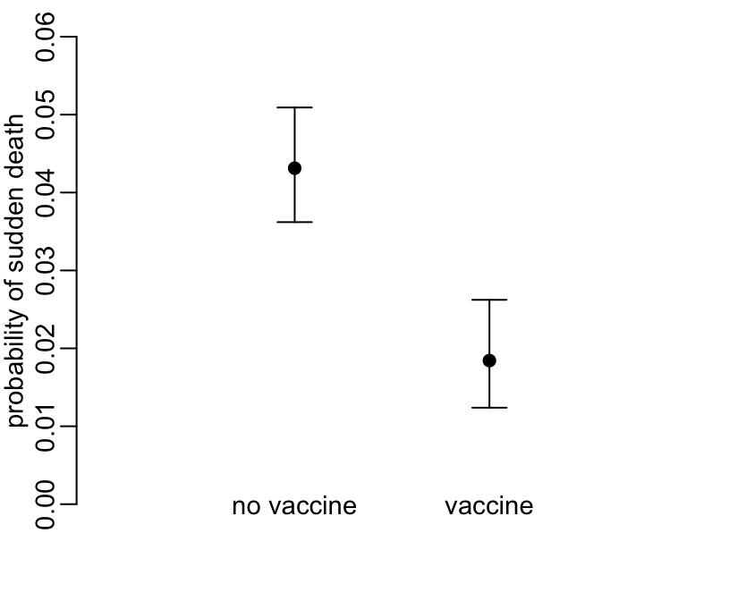

```r
> a <- viparc %>%
+   dplyr::select(duration, mortality, PM.vaccinated) %>%
+   split(.$PM.vaccinated)
> without <- exp(coef(glm(cbind(mortality, duration - mortality) ~ 1, binomial, a[[1]])))
> without_ci <- exp(confint(glm(cbind(mortality, duration - mortality) ~ 1, binomial, a[[1]])))
Waiting for profiling to be done...
> with <- exp(coef(glm(cbind(mortality, duration - mortality) ~ 1, binomial, a[[2]])))
> with_ci <- exp(confint(glm(cbind(mortality, duration - mortality) ~ 1, binomial, a[[2]])))
Waiting for profiling to be done...
> plot(1:2, c(without, with), xlim = c(0, 3), ylim = c(0, .06), xlab = NA, ylab = "probability of sudden death", axes = FALSE, pch = 19)
> axis(2)
> arrows(1, without_ci[1], 1, without_ci[2], .1, 90, 3)
> arrows(2, with_ci[1], 2, with_ci[2], .1, 90, 3)
> text(1, 0, "no vaccine")
> text(2, 0, "vaccine")
```

IBD vaccine seems to protect against diarrhoea:

```r
> summary(glm(cbind(diarrhoea, duration - diarrhoea) ~ IBD.vaccinated, binomial, viparc))

Call:
glm(formula = cbind(diarrhoea, duration - diarrhoea) ~ IBD.vaccinated,
    family = binomial, data = viparc)

Deviance Residuals:
   Min      1Q  Median      3Q     Max
-1.886  -1.383  -1.269   0.352   5.062

Coefficients:
                   Estimate Std. Error z value Pr(>|z|)
(Intercept)         -2.5649     0.1399 -18.330   <2e-16 ***
IBD.vaccinatedTRUE  -0.3988     0.1574  -2.533   0.0113 *
---
Signif. codes:  0 '***' 0.001 '**' 0.01 '*' 0.05 '.' 0.1 ' ' 1

(Dispersion parameter for binomial family taken to be 1)

    Null deviance: 600.66  on 266  degrees of freedom
Residual deviance: 594.66  on 265  degrees of freedom
AIC: 864.9

Number of Fisher Scoring iterations: 5
```

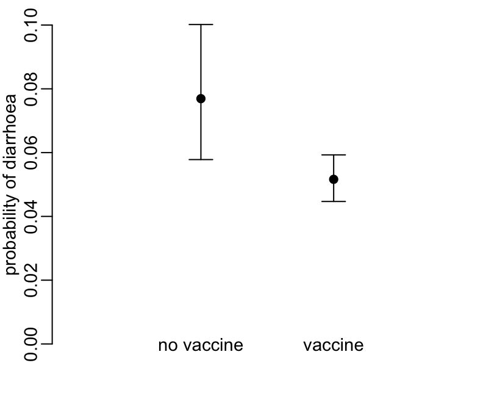

```r
> a <- viparc %>%
+   dplyr::select(duration, diarrhoea, IBD.vaccinated) %>%
+   split(.$IBD.vaccinated)
> without <- exp(coef(glm(cbind(diarrhoea, duration - diarrhoea) ~ 1, binomial, a[[1]])))
> without_ci <- exp(confint(glm(cbind(diarrhoea, duration - diarrhoea) ~ 1, binomial, a[[1]])))
Waiting for profiling to be done...
> with <- exp(coef(glm(cbind(diarrhoea, duration - diarrhoea) ~ 1, binomial, a[[2]])))
> with_ci <- exp(confint(glm(cbind(diarrhoea, duration - diarrhoea) ~ 1, binomial, a[[2]])))
Waiting for profiling to be done...
> plot(1:2, c(without, with), xlim = c(0, 3), ylim = c(0, .1), xlab = NA, ylab = "probability of diarrhoea", axes = FALSE, pch = 19)
> axis(2)
> arrows(1, without_ci[1], 1, without_ci[2], .1, 90, 3)
> arrows(2, with_ci[1], 2, with_ci[2], .1, 90, 3)
> text(1, 0, "no vaccine")
> text(2, 0, "vaccine")
```

## Another shot at the relationship between symptoms and vaccination

```r
> fig1 <- readr::read_csv("Figure1.csv") %>%
+   dplyr::select(-CODE) %>%
+   dplyr::mutate_if(is.numeric, as.integer) %>%
+   dplyr::arrange(WEEKNO)
Parsed with column specification:
cols(
  FlockID = col_character(),
  WEEKNO = col_double(),
  Fowl.Pox.vaccinated = col_double(),
  HPAI.vaccinated = col_double(),
  NDV.vaccinated = col_double(),
  IBV.vaccinated = col_double(),
  IBD.vaccinated = col_double(),
  PM.vaccinated = col_double(),
  CODE = col_character()
)
```

```r
> g <- function(vacc_name) {
+   fig1[, c("FlockID", "WEEKNO", vacc_name)] %>%
+   unique() %>%
+   split(.$FlockID)
+ }
```

```r
> f <- function(df) {
+   vacc_names <- grep("vaccinated", names(df))
+   out <- setNames(data.frame(df$FlockID[1], seq_len(max(df$WEEKNO)), 0L, stringsAsFactors = FALSE), names(df))
+   first <- which(df[, vacc_names] > 0)[1]
+   if (is.na(first)) return(out)
+   out[first:nrow(out), vacc_names] <- 1L
+   out
+ }
```

```r
> viparc <- readr::read_csv("https://raw.githubusercontent.com/viparc/clires_data/master/data/viparc.csv",
+                           col_types = paste(rep(c("c", "i", "l", "i", "d", "l", "d"), c(1, 2, 2, 1, 3, 6, 45)), collapse = "")) %>%
+   dplyr::mutate(FlockID = paste0(farm, flock))
```

```r
> vacc_data <- names(fig1) %>%
+   setdiff(c("FlockID", "WEEKNO")) %>%
+   lapply(g) %>%
+   lapply(function(x) dplyr::bind_rows(lapply(x, f))) %>%
+   purrr::reduce(dplyr::left_join, c("FlockID", "WEEKNO")) %>%
+   dplyr::left_join(viparc, "FlockID") %>%
+   dplyr::select(farm, flock, week, respiratory, diarrhoea, cns, sudden_death, ends_with("vaccinated")) %>%
+   dplyr::mutate_at(dplyr::vars(dplyr::ends_with("vaccinated")), as.logical)
```

Same result as before for the effects of AI and IBV vaccines:

```r
> mod <- glm(respiratory ~ NDV.vaccinated + HPAI.vaccinated + IBV.vaccinated + IBD.vaccinated, binomial, vacc_data)
> summary(mod)

Call:
glm(formula = respiratory ~ NDV.vaccinated + HPAI.vaccinated +
    IBV.vaccinated + IBD.vaccinated, family = binomial, data = vacc_data)

Deviance Residuals:
    Min       1Q   Median       3Q      Max
-0.3726  -0.2884  -0.2818  -0.2546   2.6753

Coefficients:
                    Estimate Std. Error z value Pr(>|z|)
(Intercept)         -3.45783    0.08012 -43.161  < 2e-16 ***
NDV.vaccinatedTRUE  -0.09242    0.07778  -1.188    0.235
HPAI.vaccinatedTRUE  0.29901    0.04014   7.450 9.33e-14 ***
IBV.vaccinatedTRUE   0.57406    0.03687  15.568  < 2e-16 ***
IBD.vaccinatedTRUE   0.04455    0.04681   0.952    0.341
---
Signif. codes:  0 '***' 0.001 '**' 0.01 '*' 0.05 '.' 0.1 ' ' 1

(Dispersion parameter for binomial family taken to be 1)

    Null deviance: 28956  on 83061  degrees of freedom
Residual deviance: 28670  on 83057  degrees of freedom
AIC: 28680

Number of Fisher Scoring iterations: 6
> car::Anova(mod, test = "LR")
Analysis of Deviance Table (Type II tests)

Response: respiratory
                LR Chisq Df Pr(>Chisq)
NDV.vaccinated     1.380  1     0.2401
HPAI.vaccinated   57.680  1  3.085e-14 ***
IBV.vaccinated   229.390  1  < 2.2e-16 ***
IBD.vaccinated     0.913  1     0.3393
---
Signif. codes:  0 '***' 0.001 '**' 0.01 '*' 0.05 '.' 0.1 ' ' 1
```

Here, both HPAI and NDV vaccines are associated with higher CNS (whereas it was only the NDV vaccine in the analysis above):

```r
> mod <- glm(cns ~ HPAI.vaccinated + NDV.vaccinated, binomial, vacc_data)
> summary(mod)

Call:
glm(formula = cns ~ HPAI.vaccinated + NDV.vaccinated, family = binomial,
    data = vacc_data)

Deviance Residuals:
    Min       1Q   Median       3Q      Max
-0.1445  -0.1445  -0.1445  -0.1319   3.5484

Coefficients:
                    Estimate Std. Error z value Pr(>|z|)
(Intercept)         -6.29374    0.31978 -19.682  < 2e-16 ***
HPAI.vaccinatedTRUE  0.18338    0.08102   2.264   0.0236 *
NDV.vaccinatedTRUE   1.55402    0.31873   4.876 1.08e-06 ***
---
Signif. codes:  0 '***' 0.001 '**' 0.01 '*' 0.05 '.' 0.1 ' ' 1

(Dispersion parameter for binomial family taken to be 1)

    Null deviance: 8844.1  on 83061  degrees of freedom
Residual deviance: 8795.2  on 83059  degrees of freedom
AIC: 8801.2

Number of Fisher Scoring iterations: 8
> car::Anova(mod, test = "LR")
Analysis of Deviance Table (Type II tests)

Response: cns
                LR Chisq Df Pr(>Chisq)
HPAI.vaccinated    5.261  1     0.0218 *
NDV.vaccinated    41.332  1  1.285e-10 ***
---
Signif. codes:  0 '***' 0.001 '**' 0.01 '*' 0.05 '.' 0.1 ' ' 1
```

Here HPAI vaccine is shown to protect against mortality, in addition to the PM vaccine. NDV vaccine now is marginally associtaed with increased risk:

```r
> mod <- glm(sudden_death ~ NDV.vaccinated + HPAI.vaccinated + PM.vaccinated, binomial, vacc_data)
> summary(mod)

Call:
glm(formula = sudden_death ~ NDV.vaccinated + HPAI.vaccinated +
    PM.vaccinated, family = binomial, data = vacc_data)

Deviance Residuals:
    Min       1Q   Median       3Q      Max
-0.3012  -0.3012  -0.2701  -0.2425   2.8095

Coefficients:
                    Estimate Std. Error z value Pr(>|z|)
(Intercept)         -3.28991    0.08458 -38.898  < 2e-16 ***
NDV.vaccinatedTRUE   0.21934    0.08529   2.572   0.0101 *
HPAI.vaccinatedTRUE -0.22231    0.04024  -5.525 3.29e-08 ***
PM.vaccinatedTRUE   -0.63433    0.06039 -10.504  < 2e-16 ***
---
Signif. codes:  0 '***' 0.001 '**' 0.01 '*' 0.05 '.' 0.1 ' ' 1

(Dispersion parameter for binomial family taken to be 1)

    Null deviance: 24983  on 83061  degrees of freedom
Residual deviance: 24779  on 83058  degrees of freedom
AIC: 24787

Number of Fisher Scoring iterations: 6
> car::Anova(mod, test = "LR")
Analysis of Deviance Table (Type II tests)

Response: sudden_death
                LR Chisq Df Pr(>Chisq)
NDV.vaccinated     7.027  1   0.008027 **
HPAI.vaccinated   30.134  1  4.033e-08 ***
PM.vaccinated    125.662  1  < 2.2e-16 ***
---
Signif. codes:  0 '***' 0.001 '**' 0.01 '*' 0.05 '.' 0.1 ' ' 1
```

Comparin with all the symptoms:

```r
> mod1 <- glm(sudden_death ~ NDV.vaccinated + HPAI.vaccinated + PM.vaccinated, binomial, vacc_data)
> mod2 <- glm(sudden_death ~ NDV.vaccinated + HPAI.vaccinated + PM.vaccinated + IBV.vaccinated + IBD.vaccinated + Fowl.Pox.vaccinated, binomial, vacc_data)
> summary(mod1)

Call:
glm(formula = sudden_death ~ NDV.vaccinated + HPAI.vaccinated +
    PM.vaccinated, family = binomial, data = vacc_data)

Deviance Residuals:
    Min       1Q   Median       3Q      Max
-0.3012  -0.3012  -0.2701  -0.2425   2.8095

Coefficients:
                    Estimate Std. Error z value Pr(>|z|)
(Intercept)         -3.28991    0.08458 -38.898  < 2e-16 ***
NDV.vaccinatedTRUE   0.21934    0.08529   2.572   0.0101 *
HPAI.vaccinatedTRUE -0.22231    0.04024  -5.525 3.29e-08 ***
PM.vaccinatedTRUE   -0.63433    0.06039 -10.504  < 2e-16 ***
---
Signif. codes:  0 '***' 0.001 '**' 0.01 '*' 0.05 '.' 0.1 ' ' 1

(Dispersion parameter for binomial family taken to be 1)

    Null deviance: 24983  on 83061  degrees of freedom
Residual deviance: 24779  on 83058  degrees of freedom
AIC: 24787

Number of Fisher Scoring iterations: 6
> summary(mod2)

Call:
glm(formula = sudden_death ~ NDV.vaccinated + HPAI.vaccinated +
    PM.vaccinated + IBV.vaccinated + IBD.vaccinated + Fowl.Pox.vaccinated,
    family = binomial, data = vacc_data)

Deviance Residuals:
    Min       1Q   Median       3Q      Max
-0.4562  -0.2488  -0.2158  -0.1729   2.9083

Coefficients:
                        Estimate Std. Error z value Pr(>|z|)
(Intercept)             -3.52608    0.08738 -40.352  < 2e-16 ***
NDV.vaccinatedTRUE       0.06596    0.08868   0.744   0.4570
HPAI.vaccinatedTRUE     -0.20098    0.04105  -4.896 9.76e-07 ***
PM.vaccinatedTRUE       -0.01855    0.06472  -0.287   0.7744
IBV.vaccinatedTRUE       1.24994    0.04278  29.217  < 2e-16 ***
IBD.vaccinatedTRUE      -0.08675    0.05064  -1.713   0.0867 .
Fowl.Pox.vaccinatedTRUE -0.44796    0.05017  -8.928  < 2e-16 ***
---
Signif. codes:  0 '***' 0.001 '**' 0.01 '*' 0.05 '.' 0.1 ' ' 1

(Dispersion parameter for binomial family taken to be 1)

    Null deviance: 24983  on 83061  degrees of freedom
Residual deviance: 23581  on 83055  degrees of freedom
AIC: 23595

Number of Fisher Scoring iterations: 6
> car::Anova(mod1, test = "LR")
Analysis of Deviance Table (Type II tests)

Response: sudden_death
                LR Chisq Df Pr(>Chisq)
NDV.vaccinated     7.027  1   0.008027 **
HPAI.vaccinated   30.134  1  4.033e-08 ***
PM.vaccinated    125.662  1  < 2.2e-16 ***
---
Signif. codes:  0 '***' 0.001 '**' 0.01 '*' 0.05 '.' 0.1 ' ' 1
> car::Anova(mod2, test = "LR")
Analysis of Deviance Table (Type II tests)

Response: sudden_death
                    LR Chisq Df Pr(>Chisq)
NDV.vaccinated          0.56  1     0.4536
HPAI.vaccinated        23.72  1  1.115e-06 ***
PM.vaccinated           0.08  1     0.7741
IBV.vaccinated        864.07  1  < 2.2e-16 ***
IBD.vaccinated          2.90  1     0.0886 .
Fowl.Pox.vaccinated    83.97  1  < 2.2e-16 ***
---
Signif. codes:  0 '***' 0.001 '**' 0.01 '*' 0.05 '.' 0.1 ' ' 1
```

```r
> mod1 <- glm(cns ~ HPAI.vaccinated + NDV.vaccinated, binomial, vacc_data)
> mod2 <- glm(cns ~ HPAI.vaccinated + NDV.vaccinated + PM.vaccinated + IBV.vaccinated + IBD.vaccinated + Fowl.Pox.vaccinated, binomial, vacc_data)
> summary(mod1)

Call:
glm(formula = cns ~ HPAI.vaccinated + NDV.vaccinated, family = binomial,
    data = vacc_data)

Deviance Residuals:
    Min       1Q   Median       3Q      Max
-0.1445  -0.1445  -0.1445  -0.1319   3.5484

Coefficients:
                    Estimate Std. Error z value Pr(>|z|)
(Intercept)         -6.29374    0.31978 -19.682  < 2e-16 ***
HPAI.vaccinatedTRUE  0.18338    0.08102   2.264   0.0236 *
NDV.vaccinatedTRUE   1.55402    0.31873   4.876 1.08e-06 ***
---
Signif. codes:  0 '***' 0.001 '**' 0.01 '*' 0.05 '.' 0.1 ' ' 1

(Dispersion parameter for binomial family taken to be 1)

    Null deviance: 8844.1  on 83061  degrees of freedom
Residual deviance: 8795.2  on 83059  degrees of freedom
AIC: 8801.2

Number of Fisher Scoring iterations: 8
> summary(mod2)

Call:
glm(formula = cns ~ HPAI.vaccinated + NDV.vaccinated + PM.vaccinated +
    IBV.vaccinated + IBD.vaccinated + Fowl.Pox.vaccinated, family = binomial,
    data = vacc_data)

Deviance Residuals:
    Min       1Q   Median       3Q      Max
-0.2269  -0.1489  -0.1328  -0.0793   3.5083

Coefficients:
                        Estimate Std. Error z value Pr(>|z|)
(Intercept)             -6.29114    0.32652 -19.268  < 2e-16 ***
HPAI.vaccinatedTRUE     -0.18783    0.09101  -2.064    0.039 *
NDV.vaccinatedTRUE       1.59159    0.32132   4.953  7.3e-07 ***
PM.vaccinatedTRUE        0.84980    0.08347  10.181  < 2e-16 ***
IBV.vaccinatedTRUE      -1.26459    0.14397  -8.784  < 2e-16 ***
IBD.vaccinatedTRUE       0.20286    0.10660   1.903    0.057 .
Fowl.Pox.vaccinatedTRUE -0.04141    0.08490  -0.488    0.626
---
Signif. codes:  0 '***' 0.001 '**' 0.01 '*' 0.05 '.' 0.1 ' ' 1

(Dispersion parameter for binomial family taken to be 1)

    Null deviance: 8844.1  on 83061  degrees of freedom
Residual deviance: 8511.1  on 83055  degrees of freedom
AIC: 8525.1

Number of Fisher Scoring iterations: 8
> car::Anova(mod1, test = "LR")
Analysis of Deviance Table (Type II tests)

Response: cns
                LR Chisq Df Pr(>Chisq)
HPAI.vaccinated    5.261  1     0.0218 *
NDV.vaccinated    41.332  1  1.285e-10 ***
---
Signif. codes:  0 '***' 0.001 '**' 0.01 '*' 0.05 '.' 0.1 ' ' 1
> car::Anova(mod2, test = "LR")
Analysis of Deviance Table (Type II tests)

Response: cns
                    LR Chisq Df Pr(>Chisq)
HPAI.vaccinated        4.193  1    0.04060 *
NDV.vaccinated        41.840  1  9.908e-11 ***
PM.vaccinated        101.562  1  < 2.2e-16 ***
IBV.vaccinated       101.907  1  < 2.2e-16 ***
IBD.vaccinated         3.727  1    0.05353 .
Fowl.Pox.vaccinated    0.238  1    0.62595
---
Signif. codes:  0 '***' 0.001 '**' 0.01 '*' 0.05 '.' 0.1 ' ' 1
```

```r
> mod1 <- glm(respiratory ~ NDV.vaccinated + HPAI.vaccinated + IBV.vaccinated + IBD.vaccinated, binomial, vacc_data)
> mod2 <- glm(respiratory ~ NDV.vaccinated + HPAI.vaccinated + IBV.vaccinated + IBD.vaccinated + PM.vaccinated + Fowl.Pox.vaccinated, binomial, vacc_data)
> summary(mod1)

Call:
glm(formula = respiratory ~ NDV.vaccinated + HPAI.vaccinated +
    IBV.vaccinated + IBD.vaccinated, family = binomial, data = vacc_data)

Deviance Residuals:
    Min       1Q   Median       3Q      Max
-0.3726  -0.2884  -0.2818  -0.2546   2.6753

Coefficients:
                    Estimate Std. Error z value Pr(>|z|)
(Intercept)         -3.45783    0.08012 -43.161  < 2e-16 ***
NDV.vaccinatedTRUE  -0.09242    0.07778  -1.188    0.235
HPAI.vaccinatedTRUE  0.29901    0.04014   7.450 9.33e-14 ***
IBV.vaccinatedTRUE   0.57406    0.03687  15.568  < 2e-16 ***
IBD.vaccinatedTRUE   0.04455    0.04681   0.952    0.341
---
Signif. codes:  0 '***' 0.001 '**' 0.01 '*' 0.05 '.' 0.1 ' ' 1

(Dispersion parameter for binomial family taken to be 1)

    Null deviance: 28956  on 83061  degrees of freedom
Residual deviance: 28670  on 83057  degrees of freedom
AIC: 28680

Number of Fisher Scoring iterations: 6
> summary(mod2)

Call:
glm(formula = respiratory ~ NDV.vaccinated + HPAI.vaccinated +
    IBV.vaccinated + IBD.vaccinated + PM.vaccinated + Fowl.Pox.vaccinated,
    family = binomial, data = vacc_data)

Deviance Residuals:
    Min       1Q   Median       3Q      Max
-0.5205  -0.3317  -0.3006  -0.2124   2.8196

Coefficients:
                        Estimate Std. Error z value Pr(>|z|)
(Intercept)             -3.36460    0.07967 -42.232  < 2e-16 ***
NDV.vaccinatedTRUE      -0.41530    0.08083  -5.138 2.78e-07 ***
HPAI.vaccinatedTRUE      0.16903    0.04179   4.045 5.24e-05 ***
IBV.vaccinatedTRUE       0.91438    0.04162  21.972  < 2e-16 ***
IBD.vaccinatedTRUE      -0.17627    0.04862  -3.625 0.000289 ***
PM.vaccinatedTRUE        0.22960    0.04563   5.032 4.86e-07 ***
Fowl.Pox.vaccinatedTRUE  0.71248    0.04097  17.390  < 2e-16 ***
---
Signif. codes:  0 '***' 0.001 '**' 0.01 '*' 0.05 '.' 0.1 ' ' 1

(Dispersion parameter for binomial family taken to be 1)

    Null deviance: 28956  on 83061  degrees of freedom
Residual deviance: 28295  on 83055  degrees of freedom
AIC: 28309

Number of Fisher Scoring iterations: 6
> car::Anova(mod1, test = "LR")
Analysis of Deviance Table (Type II tests)

Response: respiratory
                LR Chisq Df Pr(>Chisq)
NDV.vaccinated     1.380  1     0.2401
HPAI.vaccinated   57.680  1  3.085e-14 ***
IBV.vaccinated   229.390  1  < 2.2e-16 ***
IBD.vaccinated     0.913  1     0.3393
---
Signif. codes:  0 '***' 0.001 '**' 0.01 '*' 0.05 '.' 0.1 ' ' 1
> car::Anova(mod2, test = "LR")
Analysis of Deviance Table (Type II tests)

Response: respiratory
                    LR Chisq Df Pr(>Chisq)
NDV.vaccinated         24.19  1  8.745e-07 ***
HPAI.vaccinated        16.64  1  4.526e-05 ***
IBV.vaccinated        461.58  1  < 2.2e-16 ***
IBD.vaccinated         12.80  1  0.0003461 ***
PM.vaccinated          24.88  1  6.091e-07 ***
Fowl.Pox.vaccinated   301.65  1  < 2.2e-16 ***
---
Signif. codes:  0 '***' 0.001 '**' 0.01 '*' 0.05 '.' 0.1 ' ' 1
```

```r
> mod1 <- glm(diarrhoea ~ IBD.vaccinated, binomial, vacc_data)
> mod2 <- glm(diarrhoea ~ IBD.vaccinated + NDV.vaccinated + HPAI.vaccinated + IBV.vaccinated + PM.vaccinated + Fowl.Pox.vaccinated, binomial, vacc_data)
> summary(mod1)

Call:
glm(formula = diarrhoea ~ IBD.vaccinated, family = binomial,
    data = vacc_data)

Deviance Residuals:
    Min       1Q   Median       3Q      Max
-0.3761  -0.3188  -0.3188  -0.3188   2.4514

Coefficients:
                   Estimate Std. Error z value Pr(>|z|)
(Intercept)        -2.61348    0.03046 -85.809   <2e-16 ***
IBD.vaccinatedTRUE -0.34049    0.03534  -9.635   <2e-16 ***
---
Signif. codes:  0 '***' 0.001 '**' 0.01 '*' 0.05 '.' 0.1 ' ' 1

(Dispersion parameter for binomial family taken to be 1)

    Null deviance: 34607  on 83061  degrees of freedom
Residual deviance: 34519  on 83060  degrees of freedom
AIC: 34523

Number of Fisher Scoring iterations: 5
> summary(mod2)

Call:
glm(formula = diarrhoea ~ IBD.vaccinated + NDV.vaccinated + HPAI.vaccinated +
    IBV.vaccinated + PM.vaccinated + Fowl.Pox.vaccinated, family = binomial,
    data = vacc_data)

Deviance Residuals:
    Min       1Q   Median       3Q      Max
-0.4197  -0.3514  -0.3127  -0.3090   2.6597

Coefficients:
                        Estimate Std. Error z value Pr(>|z|)
(Intercept)             -2.63462    0.06453 -40.826  < 2e-16 ***
IBD.vaccinatedTRUE      -0.35596    0.03837  -9.277  < 2e-16 ***
NDV.vaccinatedTRUE      -0.08654    0.06396  -1.353   0.1761
HPAI.vaccinatedTRUE      0.24955    0.03606   6.920 4.53e-12 ***
IBV.vaccinatedTRUE      -0.19039    0.04071  -4.677 2.91e-06 ***
PM.vaccinatedTRUE       -0.23985    0.04328  -5.542 2.99e-08 ***
Fowl.Pox.vaccinatedTRUE  0.07390    0.03630   2.036   0.0418 *
---
Signif. codes:  0 '***' 0.001 '**' 0.01 '*' 0.05 '.' 0.1 ' ' 1

(Dispersion parameter for binomial family taken to be 1)

    Null deviance: 34607  on 83061  degrees of freedom
Residual deviance: 34423  on 83055  degrees of freedom
AIC: 34437

Number of Fisher Scoring iterations: 5
> car::Anova(mod2, test = "LR")
Analysis of Deviance Table (Type II tests)

Response: diarrhoea
                    LR Chisq Df Pr(>Chisq)
IBD.vaccinated        82.998  1  < 2.2e-16 ***
NDV.vaccinated         1.797  1    0.18011
HPAI.vaccinated       48.964  1  2.608e-12 ***
IBV.vaccinated        22.393  1  2.222e-06 ***
PM.vaccinated         31.620  1  1.875e-08 ***
Fowl.Pox.vaccinated    4.136  1    0.04199 *
---
Signif. codes:  0 '***' 0.001 '**' 0.01 '*' 0.05 '.' 0.1 ' ' 1
```

Figures:

```r
> mod1 <- glm(respiratory ~ NDV.vaccinated + HPAI.vaccinated + PM.vaccinated + IBV.vaccinated + IBD.vaccinated + Fowl.Pox.vaccinated, binomial, vacc_data)
> mod2 <- glm(sudden_death ~ NDV.vaccinated + HPAI.vaccinated + PM.vaccinated + IBV.vaccinated + IBD.vaccinated + Fowl.Pox.vaccinated, binomial, vacc_data)
> mod3 <- glm(diarrhoea ~ NDV.vaccinated + HPAI.vaccinated + PM.vaccinated + IBV.vaccinated + IBD.vaccinated + Fowl.Pox.vaccinated, binomial, vacc_data)
> mod4 <- glm(cns ~ NDV.vaccinated + HPAI.vaccinated + PM.vaccinated + IBV.vaccinated + IBD.vaccinated + Fowl.Pox.vaccinated, binomial, vacc_data)
```

```r
> ct1 <- coef(mod1)
> ct2 <- coef(mod2)
> ct3 <- coef(mod3)
> ct4 <- coef(mod4)
> ci1 <- confint(mod1)
Waiting for profiling to be done...
> ci2 <- confint(mod2)
Waiting for profiling to be done...
> ci3 <- confint(mod3)
Waiting for profiling to be done...
> ci4 <- confint(mod4)
Waiting for profiling to be done...
```

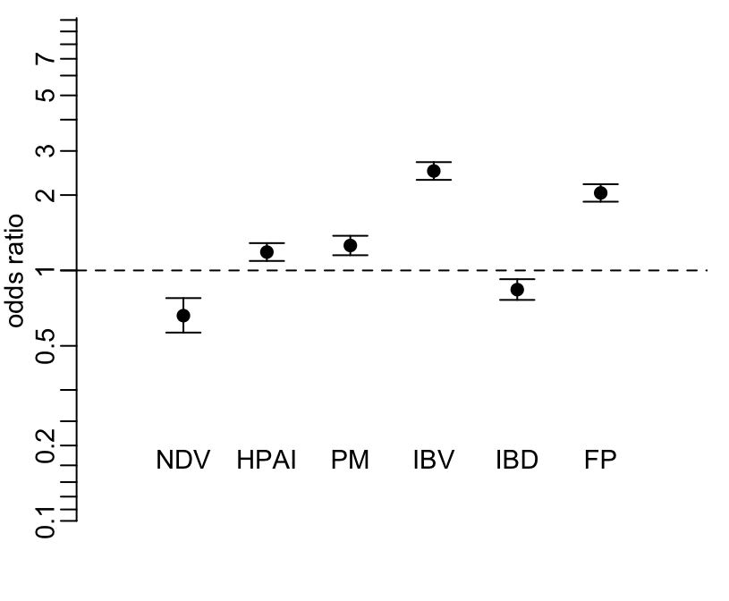

```r
> xs <- 1:6
> ys <- c(1 / seq(0, 10, 1), 1 + seq(0, 10, 1))
> f <- function(x) log2(exp(x))
> plot(xs, f(ct1[-1]), pch = 19, xlim = c(0, 7), ylim = c(-3.1, 3.1), axes = FALSE, xlab = NA, ylab = "odds ratio")
> axis(2, log2(ys), ys)
> text(xs, -2.5, c("NDV", "HPAI", "PM", "IBV", "IBD", "FP"))
> arrows(xs, f(ci1[-1, 1]), xs, f(ci1[-1, 2]), .1, 90, 3)
> abline(h = 0, lty = 2)
```

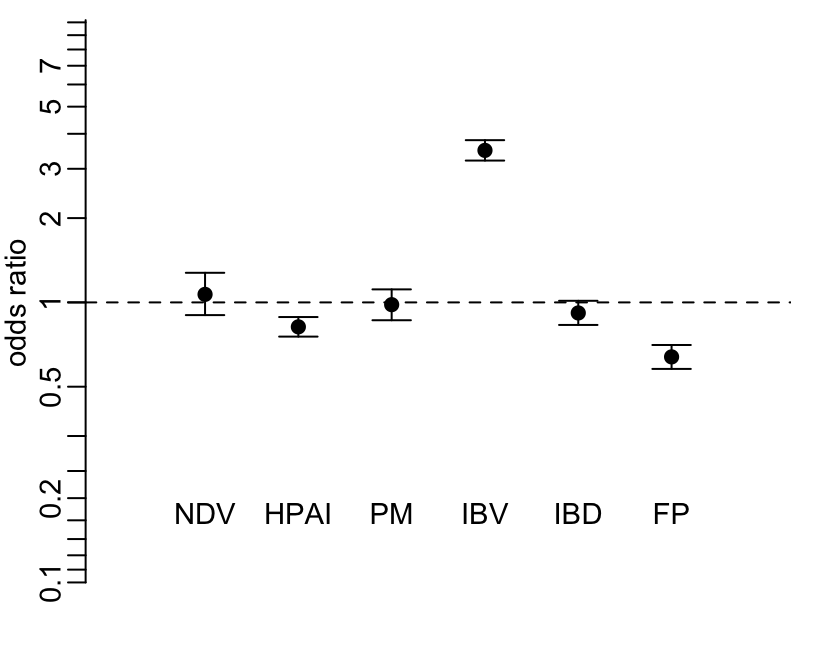

```r
> xs <- 1:6
> ys <- c(1 / seq(0, 10, 1), 1 + seq(0, 10, 1))
> f <- function(x) log2(exp(x))
> plot(xs, f(ct2[-1]), pch = 19, xlim = c(0, 7), ylim = c(-3.1, 3.1), axes = FALSE, xlab = NA, ylab = "odds ratio")
> axis(2, log2(ys), ys)
> text(xs, -2.5, c("NDV", "HPAI", "PM", "IBV", "IBD", "FP"))
> arrows(xs, f(ci2[-1, 1]), xs, f(ci2[-1, 2]), .1, 90, 3)
> abline(h = 0, lty = 2)
```

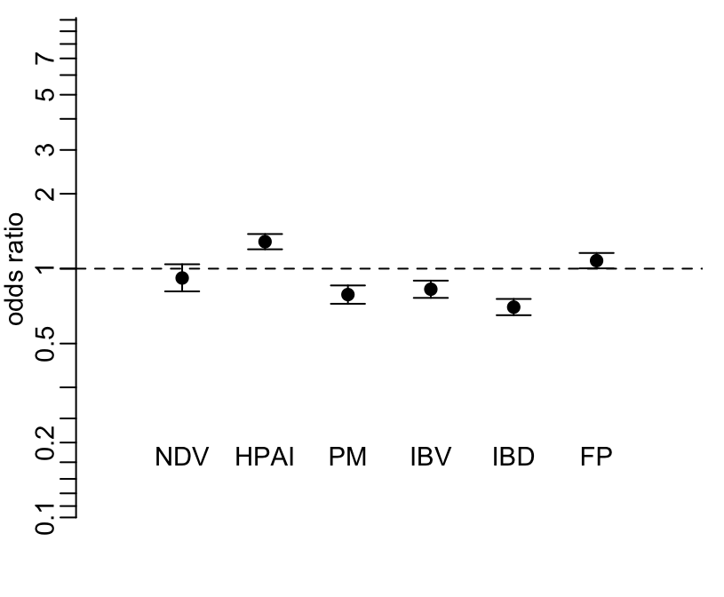

```r
> xs <- 1:6
> ys <- c(1 / seq(0, 10, 1), 1 + seq(0, 10, 1))
> f <- function(x) log2(exp(x))
> plot(xs, f(ct3[-1]), pch = 19, xlim = c(0, 7), ylim = c(-3.1, 3.1), axes = FALSE, xlab = NA, ylab = "odds ratio")
> axis(2, log2(ys), ys)
> text(xs, -2.5, c("NDV", "HPAI", "PM", "IBV", "IBD", "FP"))
> arrows(xs, f(ci3[-1, 1]), xs, f(ci3[-1, 2]), .1, 90, 3)
> abline(h = 0, lty = 2)
```

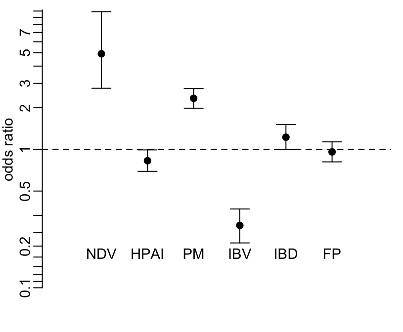

```r
> xs <- 1:6
> ys <- c(1 / seq(0, 10, 1), 1 + seq(0, 10, 1))
> f <- function(x) log2(exp(x))
> plot(xs, f(ct4[-1]), pch = 19, xlim = c(0, 7), ylim = c(-3.1, 3.1), axes = FALSE, xlab = NA, ylab = "odds ratio")
> axis(2, log2(ys), ys)
> text(xs, -2.5, c("NDV", "HPAI", "PM", "IBV", "IBD", "FP"))
> arrows(xs, f(ci4[-1, 1]), xs, f(ci4[-1, 2]), .1, 90, 3)
> abline(h = 0, lty = 2)
```

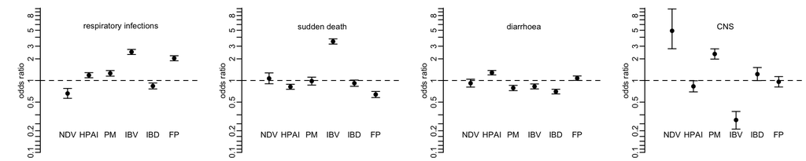

```r
> xs <- 1:6
> ys <- c(1 / seq(0, 10, 1), 1 + seq(0, 10, 1))
> f <- function(x) log2(exp(x))
>
> opar <- par(mfrow = c(1, 4), plt = c(.2, 1, .05, .95))
>
> plot(xs, f(ct1[-1]), pch = 19, xlim = c(0, 7), ylim = c(-3.1, 3.1), axes = FALSE, xlab = NA, ylab = "odds ratio")
> axis(2, log2(ys), ys)
> text(3.5, 2.5, "respiratory infections")
> text(xs, -2.5, c("NDV", "HPAI", "PM", "IBV", "IBD", "FP"))
> arrows(xs, f(ci1[-1, 1]), xs, f(ci1[-1, 2]), .05, 90, 3)
> abline(h = 0, lty = 2)
>
> plot(xs, f(ct2[-1]), pch = 19, xlim = c(0, 7), ylim = c(-3.1, 3.1), axes = FALSE, xlab = NA, ylab = "odds ratio")
> axis(2, log2(ys), ys)
> text(3.5, 2.5, "sudden death")
> text(xs, -2.5, c("NDV", "HPAI", "PM", "IBV", "IBD", "FP"))
> arrows(xs, f(ci2[-1, 1]), xs, f(ci2[-1, 2]), .05, 90, 3)
> abline(h = 0, lty = 2)
>
> plot(xs, f(ct3[-1]), pch = 19, xlim = c(0, 7), ylim = c(-3.1, 3.1), axes = FALSE, xlab = NA, ylab = "odds ratio")
> axis(2, log2(ys), ys)
> text(3.5, 2.5, "diarrhoea")
> text(xs, -2.5, c("NDV", "HPAI", "PM", "IBV", "IBD", "FP"))
> arrows(xs, f(ci3[-1, 1]), xs, f(ci3[-1, 2]), .05, 90, 3)
> abline(h = 0, lty = 2)
>
> plot(xs, f(ct4[-1]), pch = 19, xlim = c(0, 7), ylim = c(-3.1, 3.1), axes = FALSE, xlab = NA, ylab = "odds ratio")
> axis(2, log2(ys), ys)
> text(3.5, 2.5, "CNS")
> text(xs, -2.5, c("NDV", "HPAI", "PM", "IBV", "IBD", "FP"))
> arrows(xs, f(ci4[-1, 1]), xs, f(ci4[-1, 2]), .05, 90, 3)
> abline(h = 0, lty = 2)
```

```r
>
> par(opar)
```

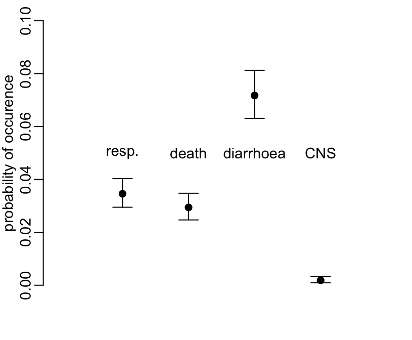

```r
> xs <- 1:4
> plot(xs, exp(c(ct1[1], ct2[1], ct3[1], ct4[1])), pch = 19, xlim = c(0, 5), ylim = c(0, .1), axes = FALSE, xlab = NA, ylab = "probability of occurence")
> axis(2)
> text(xs, .05, c("resp.", "death", "diarrhoea", "CNS"))
> arrows(xs, exp(c(ci1[1, 1], ci2[1, 1], ci3[1, 1], ci4[1, 1])), xs, exp(c(ci1[1, 2], ci2[1, 2], ci3[1, 2], ci4[1, 2])), .1, 90, 3)
```